# Data Visualization and Reproducible Research

> `@jordanrosedouglass`

For more information regarding myself and my interests, look no further than [here](https://github.com/jordanrosedouglass)

The following is a sample of products created during the *“Data Visualization and Reproducible Research”* course in Fall 2020.

## Project 01

**Favorite Viz Project 1:**

**My favorite visualization from this Mini-Project can be found below; while it’s very simple - originally the output was not smooth and gaps between data points were clearly shown. This new plot offered a smooth solid line.**

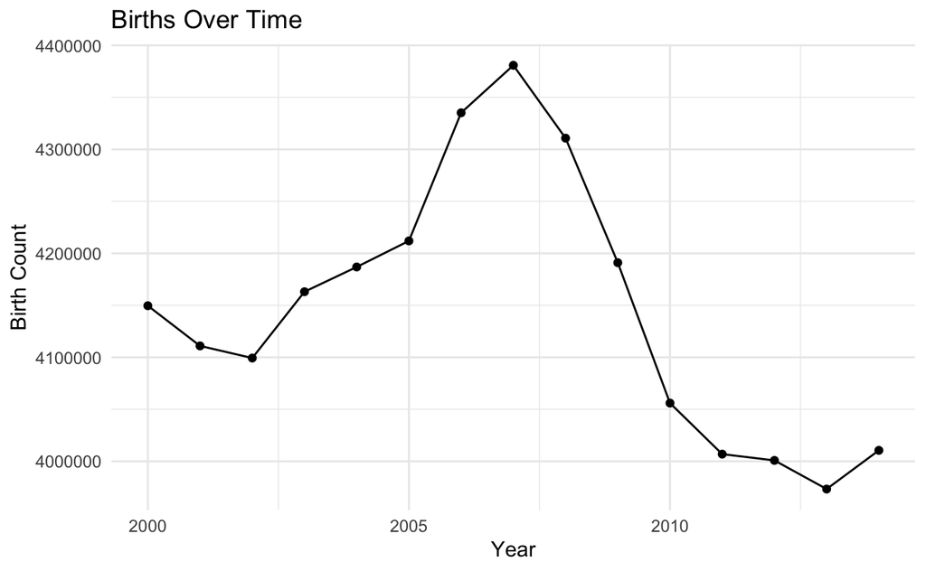

## Project 02

For the second project, I used data collected via wearable devices from a fellow FPU student’s graduate project. The devices collected systolic and diastolic blood pressure readings, heart rate and step count in fifteen minute intervals. Participants personal information was de-identified to ensure privacy. All content for this Mini Project can be found the `project_02/` [folder](https://github.com/jordanrosedouglass/dataviz_final_project/tree/main/project-02)

**Favorite Viz Project 2:**

__The visualization provided below is my favorite from Mini Project 2 - I enjoyed faceting the `systolic`, `diastolic` and `gender` variables and confirming that blood pressure linearly related to `HeartRate`.

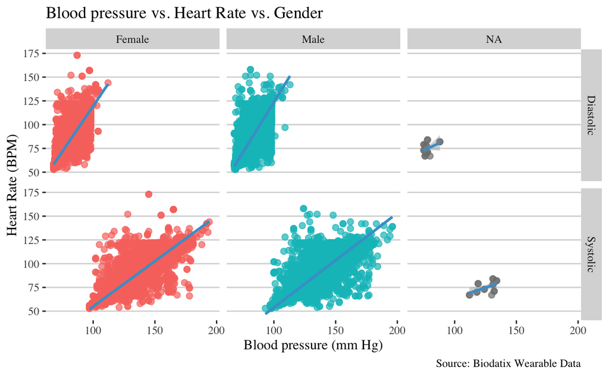

## Project 03

The third project explored Tampa weather over time. This project was interesting because it provided an opportunity to mime existing visualizations while learning how to better operate and maneuver aesthetics, geometries, scales and facets with `ggplot`.

### Moving Forward

I have used RStudio several times in the past at an introductory level. This course provided me the opportunity (and reason) to enhance visualization skills while also reinforcing skills learned in my earlier experiences.

The projects and assignments throughout this course challenged me to think freely and independently about design successes, failures and opportunities in the visualizations I create. In addition, I learned that creating visualizations is interesting and valuable.

Moving forward, I hope to be in contact with more spatial datasets and continuing to work on those skills - with the datasets used for Mini Project 2, it was difficult to fill the maps using zip codes.

Moreover, I know that each module of skills learned provide me the opportunity to further advance in future endeavors and projects.

[figure not shown]